```python
#Libreria

from IPython.display import Image
```

# Algoritmos de optimización - Seminario

Nombre y Apellidos: **Brayan Sebastian Salas Rico**

Url: https://github.com/BryanSalasRico/AlgoritmosProg-Seminario.git

Problema:

- 1. **Sesiones de doblaje**
- 2. Organizar los horarios de partidos de La Liga
- 3. Combinar cifras y operaciones

Descripción del problema:

Se precisa coordinar el doblaje de una película. Los actores del doblaje deben coincidir en las tomas en las que sus personajes aparecen juntos en las diferentes tomas. Los actores de doblaje cobran todos la misma cantidad por cada día que deben desplazarse hasta el estudio de grabación independientemente del número de tomas que se graben. No es posible grabar más de 6 tomas por día. El objetivo es planificar las sesiones por día de manera que el gasto por los servicios de los actores de doblaje sea el menor posible. Los datos son:

Numero de actores= 10

Numero de tomas = 30

1 indica que el actor participa en la toma, 0 en caso contrario

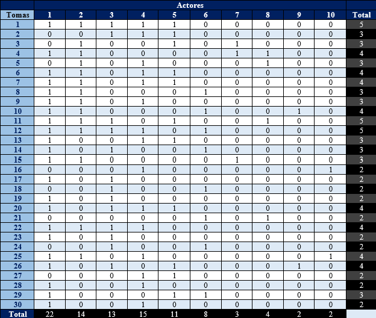

```python
Image(filename='img/tabla_problema.png')
```

### **NOTA:**

**En este documento encontrara las respuestas a las preguntas puntuales, y las respectivas explicaciones tambien puntuales. Sin embargo por favor tenga en cuenta el documento "Explicacion_Detalle.docx" en esta misma carpeta, pues ahi se encuentra toda la logica que tuve para llegar a las conclusiones aqui mostradas y como se llevaron a cabo paso a paso, ademas del glosario de cada una de las formulas.**

**Por otro lado, tenga en cuenta que los algoritmos cuentan con archivos que trabajan como checkpoint para poder realizar guardado del ultimo punto ejecutado, si quiere ejecutar algun algoritmo desde 0 debera borrarlos**

**Muchas gracias**

### **(*)¿Cuantas posibilidades hay sin tener en cuenta las restricciones?**

Entendiendo que son una cantidad de tomas maximas (T) y que al menos debe grabarse una diaria, podriamos decir que D(cantidad maxima de dias) = T (cantidad maxima de tomas). Entonces podemos afirmar que la cantidad de posibilidades que existen es **D^T** o lo que seria igual **T^T**

```python
Image(filename='img/posibilidades_sin_restricciones.png')
```

[output not shown]

### **¿Cuantas posibilidades hay teniendo en cuenta todas las restricciones?**

El problema resulta **NP-duro**, teniendo en cuenta que hay conjuntos respuesta, pero dentro de estos hay subconjuntos de respuesta. Donde un conjunto (dia) puede tener maximo 6 valores (tomas), asi que el sistema debe validar cada una de las posibles combinaciones desde el subconjunto con 1 elemento, hasya el subconjunto de 6 elementos, y realizar las distintan combinaciones entre otros subconjuntos.

### **(*) ¿Cual es la estructura de datos que mejor se adapta al problema? Argumentalo.(Es posible que hayas elegido una al principio y veas la necesidad de cambiar, argumentalo)**

Para el input del problema lo mejor es una lista de listas (a modo de tabla), donde cada fila represente una toma y cada columna el actor que participara (tal como se nos dio la informacion), esto es util para poder sacar las cuentas de los actores que estaran en x toma.

Sin embargo a nivel interno del algoritmo y para dar una respuesta, es mejor un diccionario, donde la llave sea el dia a trabajar, y el valor una lista de tomas, teniendo en cuenta que al final la organizacion que se nos pide es las tomas por dia, no los actores, estos ultimos son el valor de concecuencia al organizar la matriz respuesta.

### **(*)¿Cual es la función objetivo?**

```python
Image(filename='img/funcion_objetivo_general.png')
```

[output not shown]

Entendiendo que, lo que buscamos es minimizar la suma total de todas las combinaciones actor-día en las que el actor se presente a grabar.

**a**: Es cada actor iniciando desde el 1.

**A**: Es la cantidad máxima de actores.

**d**: cada uno de los días iniciando desde 1.

**D**: el total de días de grabación, por lo general suelen ser menos que las tomas, sin embargo, entendiendo que podría ser una toma por día, la cantidad máxima de dias va a ser igual a la cantidad máxima de tomas (D = T).

**y**: Es una variable binaria, que indica si el actor a asiste el día d.

**La funcion objetivo para el ejemplo puntual seria:**

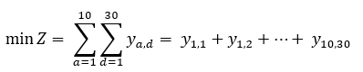

```python
Image(filename='img/funcion_objetivo_problema.png')
```

**Nota:** **Las restricciones las podra encontrar a detalle y como se llega a ellas en el archivo "Explicacion_Detalle.docx"**

### **(*)¿Es un problema de maximización o minimización?**

**Minimizacion** teniendo en cuenta que lo que se busca es la reduccion de dias que un actor debe ir al set de grabacion y reduciendo asi tambien el costo total de la produccion.

### **Diseña un algoritmo para resolver el problema por fuerza bruta**

El diseño del algoritmo se encuentra en el archivo **"Algoritmos.ipynb"**

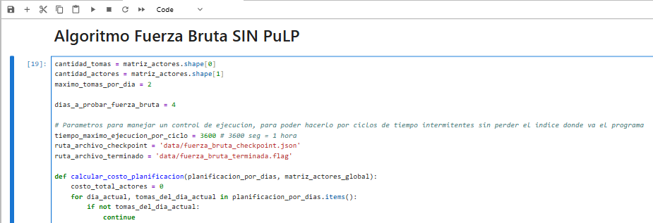

```python
Image(filename='img/algoritmo_fuerza_bruta.png')
```

sin embargo el problema es demasiado costoso a nivel computacional, lo que hace que no sea viable la ejecucion al menos desde mis recursos. Por sugerencia del docente se procede a hacer la ejecucion del ejercicio por medio de PuLP.

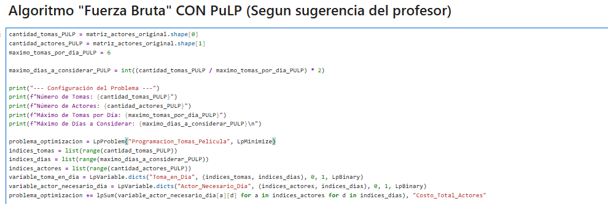

```python
Image(filename='img/algoritmo_fuerza_bruta_pulp.png')
```

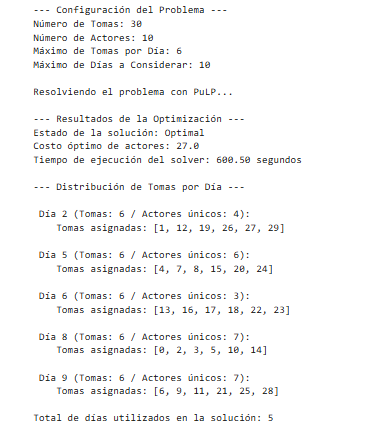

```python
Image(filename='img/resultado_fuerza_bruta_original.png')
```

### **Calcula la complejidad del algoritmo por fuerza bruta**

El algoritmo genera todas las opciones posibles de conjuntos, pero entendiendo que el ejercicio tiene subconjuntos, y que a su vez estos no tienen una longitud fija, si no que varia entre 1 y 6 (cantidad de tomas al dia), lo cual también debe tenerse en cuenta en las posibilidades. Consecuencia de esto, el algoritmo cuenta con diferentes for anidados, que hacen aumentan el orden de complejidad.

**El algoritmo sería** **de orden exponencial O(k^n)**

### **(*)Diseña un algoritmo que mejore la complejidad del algortimo por fuerza bruta. Argumenta porque crees que mejora el algoritmo por fuerza bruta**

Al inicio intente hacerlo desde un algoritmo exacto como ramificacion y poda, sin embargo aunque el coste computacional era menor, seguia siendo alto.

De acuerdo a esto, decidi hacerlo a travez de un algoritmo Heuristico **algoritmo genetico**, que se encuentra en el archivo **"Algoritmos.ipynb"** en el apartado de **Algoritmo genetico (heuristico)**

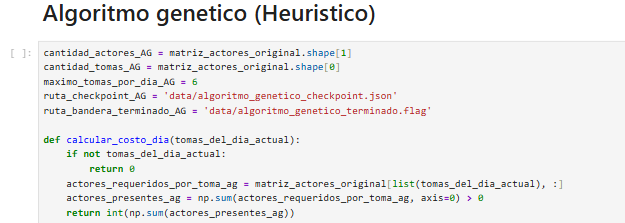

```python
Image(filename='img/algoritmo_genetico.png')
```

El algoritmo es mucho mas eficiente pues ademas que puedo manipular configuracion para decidir la cantidad limite de generaciones, o bajo un factor de proximidad a la respuesta idonea, tambien llega a conclusiones "buenas" en mucho menor tiempo. Sin embargo deja de ser exacto, y por ese motivo, en terminos de exactitud si esta por debajo.

Seria mejor una Ramificacion y poda, si lo que se busca es una respuesta exacta, si lo que se desea es porformance, esta (alg.genetico) seria una muy buena opcion.

Los resultados son mas evidentes cuando aplico un set de data aleatorio a ambos algoritmos.

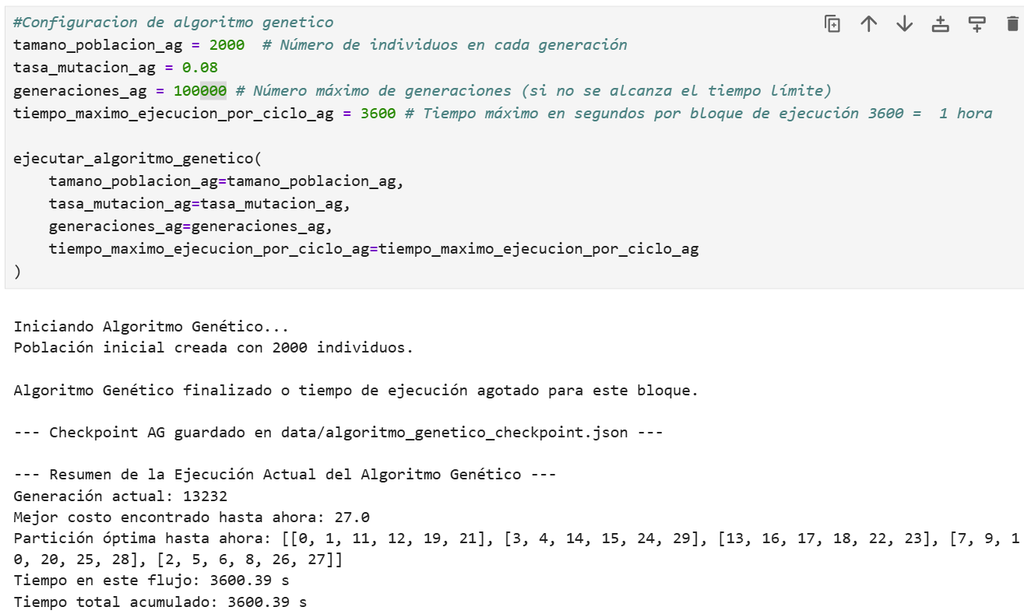

```python
Image(filename='img/resultado_algoritmo_genetico_original.png')
```

**Resultados:**

como podemos apreciar, la configuracion estaba para generar 100.000 generaciones para encontrar una respuesta acertada, sin embargo el algoritmo ya encuentra una opcion similar con el mismo coste optimo que la dada por pulp en poco mas de 13 mil en una hora de trabajo, lo que a la fuerza bruta (sin PULP) le hubiera costado mas de 40 horas.

Si seguimos bajo ese mismo ritmo, podemos decir que para mayor precision el algoritmo podria completar las 100.000 generaciones en un aproximado de 7,6 horas.

### **(*)Calcula la complejidad del algoritmo**

Teniendo en cuenta que en nuestro algoritmo influyen la cantidad de actores y tomas, asi como la cantidad de la poblacion y de generaciones que configuremos, el orden de complejidad es:

**O(g × p × T × A)**

donde:

**g:** cantidad de generaciones.

**p:** cantidad de poblacion por generacion.

**T:** cantidad total de tomas.

**A:** cantidad total de actores.

### **Según el problema (y tenga sentido), diseña un juego de datos de entrada aleatorios**

En el archivo **"Algoritmos.ipynb"** en el apartado **Importacion y generacion de matriz para algoritmos** de este mismo repositorio se encuentra la siguiente seccion de codigo:

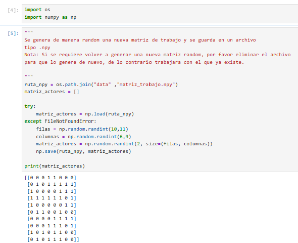

```python
Image(filename='img/set_aleatorio.png')
```

donde se crea de manera aleatoria un set de prueba, mismo que se paso por el algoritmo de fuerza bruta.

Este set se encuentra en el archivo **data/matriz_trabajo.npy** el cual no sera modificado a menos que sea borrado, en tal caso se generara de manera aleatoria uno nuevo.

### **Aplica el algoritmo al juego de datos generado**

El resultado de la implementacion del algoritmo genetico a el set de prueba aleatorio anterior es:

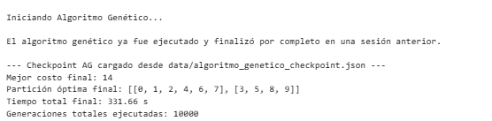

```python
Image(filename='img/resultado_algoritmo_genetico.png')
```

**frente al resultado por fuerza bruta**

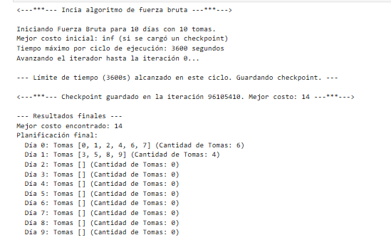

```python
Image(filename='img/resultado_fuerza_bruta.png')
```

que aunque en una primera ejecucion de una hora ya obtuvo un resultado similar con el mismo costo, no ha finalizado todo el recorrido.

esto confirma que, el performance para hayar una buena solucion al problema, es mucho mejor por parte del algoritmo genetico

recuerde que los algoritmos se encuentran en el archivo **algoritmos.ipynb** y la informacion de las ejecuciones se encuentra en la **carpeta data**. Alli estan los checkpoints y soluciones finales.

### **Enumera las referencias que has utilizado(si ha sido necesario) para llevar a cabo el trabajo**

### **Describe brevemente las lineas de como crees que es posible avanzar en el estudio del problema. Ten en cuenta incluso posibles variaciones del problema y/o variaciones al alza del tamaño**

Considero que el problema inicial es demasiado grande y costoso para desarrollarlo a traves de un algoritmo exacto (como intente hacerlo en este ejercicio pero no me fue posible). Cuando los datos son mas pequeños (como en el ejemplo que implemente) un algoritmo exacto con alguna tecnica como ramificacion y poda es lo mejor, pero mas grande que el aqui implementado, es mejor con algun algoritmo heuristico tambien implementado aca, que no asegure la mejor solucion, pero si priorice el performance. Tal vez implementando algun algoritmo voraz para lograr dividir el problema.